# INFORME COYUNTURA PAÍS VASCO

#### ·Tasa de paro

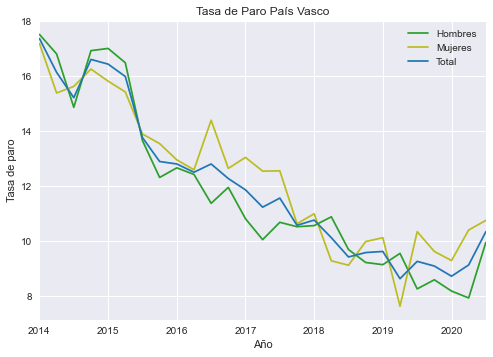

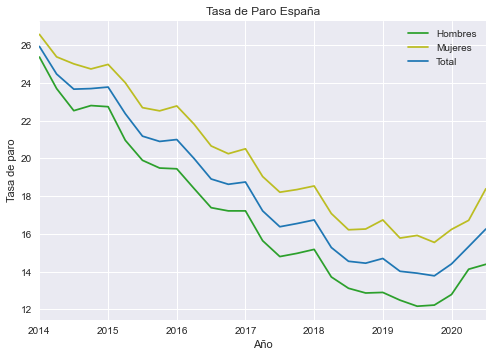

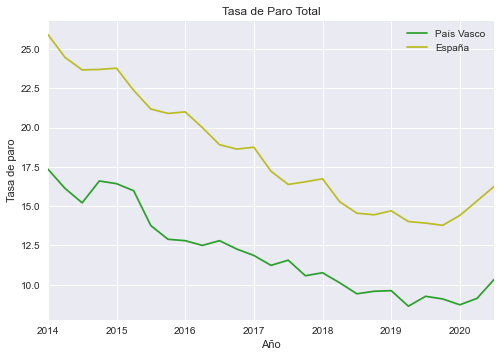

Como vemos la tasa de paro vasca es especilamente baja, habiendo llegado a niveles por debajo del 10%, algo difícil de ver en España.

#### ·Tasa de temporalidad

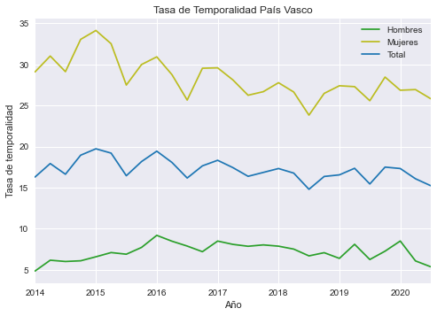

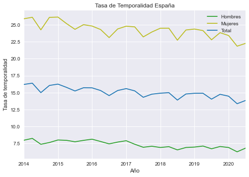

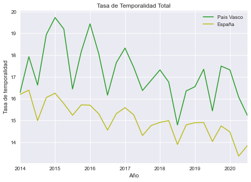

La tasa de temporalidad mide qué porcentaje de contratos son temporales respecto a la cantidad total de contratos.

Como podemos observar, ésta es bastante mayor en comparación a España. Además, posee una temporalidad más variable, con mayores caídas y subidas.

#### ·Evolución afiliación Seguridad Social

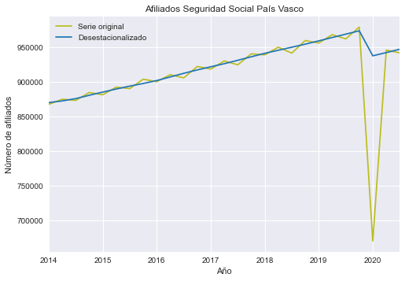

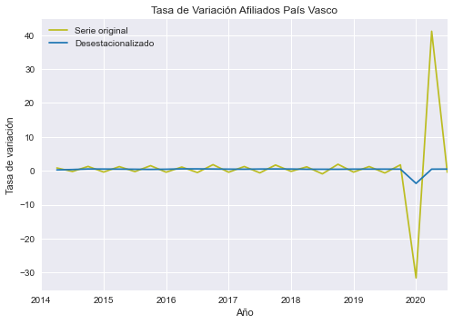

Este gráfico muestra la variación de las afiliaciones a la Seguridad Social del País Vasco, viendo como este resulta ser muy constante sin grandes alteraciones, excepto tras la reciente crisis.

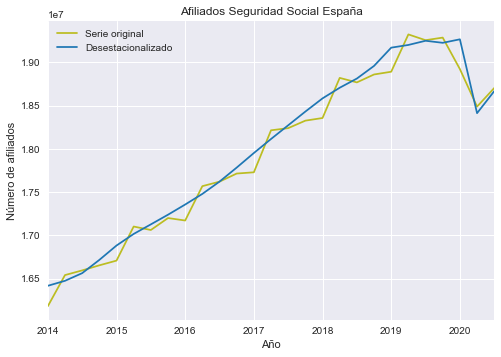

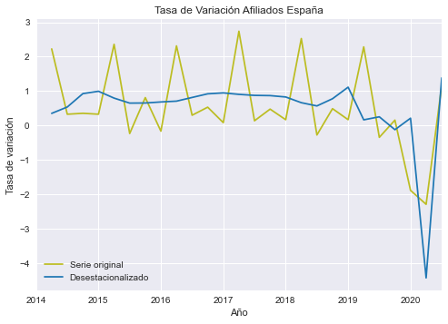

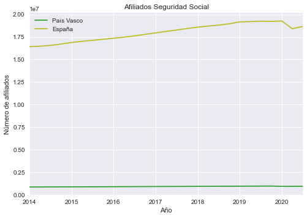

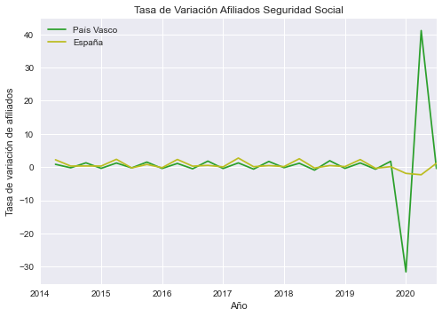

Como habíamos comentado antes la tasa de afiliación al País Vasco es muy constante siempre ligeramente por encima de cero. Aún así como habíamos visto el País Vasco tiene una temporalidad especialmente alta; y como podemos ver las bajas en la Seguridad Social en marzo fueron muy altas, al menos comprándolo con España.

En las siguientes tablas veremos los resultados:

|  | Tasa de variación afiliados País Vasco |
| --- | --- |
| 2019-10-01 00:00:00 | 1.77% |
| 2020-01-01 00:00:00 | -31.56% |
| 2020-04-01 00:00:00 | 41.14% |
| 2020-07-01 00:00:00 | -0.41% |

|  | Tasa de variación afiliados España |
| --- | --- |
| 2019-10-01 00:00:00 | 0.16% |
| 2020-01-01 00:00:00 | -1.89% |
| 2020-04-01 00:00:00 | -2.29% |
| 2020-07-01 00:00:00 | 1.16% |

#### ·Evolución desempleo registrado

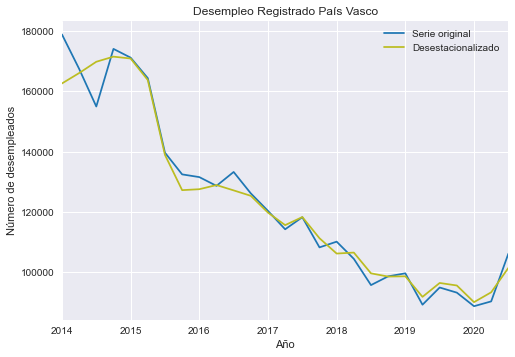

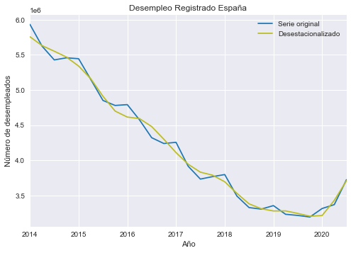

Viendo el desempleo registrado para el País Vasco y España se observa una evolución muy similar, reduciéndose en ambos casos (para la desestacionalización de ambas series hemos usado el X13).

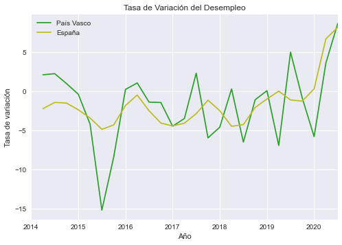

Se observa una mayor caída (relativamente) en los primeros periodos de la serie y siendo más altos en la actualidad tras la crisis, síntoma de un aumento del desempleo.

## Impacto de la Crisis y Previsiones

El impacto de la crisis sanitaria actual ha afectado a en todos los aspectos económicos, por lo que resulta útil e interesante con las técnicas de las que disponemos observar el posible funcionamiento a futuro.

Nosotros realizaremos una predicción sobre las afiliaciones, el desempleo registrado y la tasa de paro.

#### ·Impacto sobre las afiliaciones y desempleo registrado

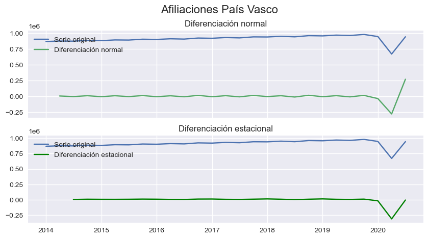

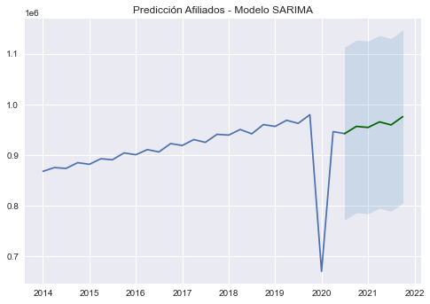

Para las afiliaciones a la Seguridad Social, en el País Vasco, se puede observar que tras la pronunciada caída la recuperación parece ser prácticamente inmediata, incluso recuperando la tendencia que poseia previamente.

[figure not shown]

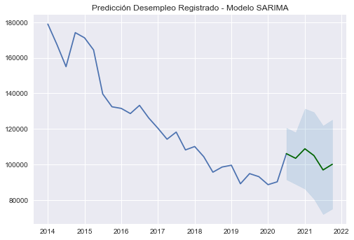

Es en el desempleo registrado donde parece ser que viene a explicar lo anterior, pero desde otro punto de vista.

El desempleo parece ser que volverá a crecer pero volviendo a encaminarse posiblemente, ya que en este caso el desempleo va a persisitir, durante al menos unos meses, alto; no siendo tan puntual como abarcaban las afiliaciones.

#### ·Predicción tasa de paro

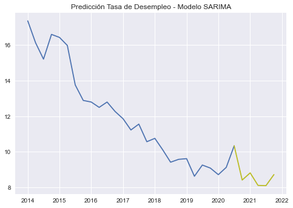

Es en este caso donde se reafirma el caso de las afiliaciones a la Seguridad Social; la tasa de paro sufrirá un repunte, aunque no parece afectar a futuro y recuperarse posteriormente.